# CE50 et CE10 sur daphnies : régression logistique

# Principe

Chaque réplicat contient 5 daphnies (les taux de survie sont des multiples de 20 %). On compte donc le **nombre de daphnies mortes sur 5**. Ce nombre suit une loi binomiale, donc on utilise un modèle logistique (`glm` avec `family = binomial`), comme dans `modèle_logistique.rmd` :

$$\text{logit}(p) = \beta_0 + \beta_1
\times \text{concentration}$$

où $p$ est la probabilité qu’une daphnie meure. La concentration pour laquelle $p$ vaut 50 % ou 10 % se déduit des coefficients :

$$CE50 = \frac{-\beta_0}{\beta_1} \qquad
CE10 = \frac{\text{logit}(0.1) - \beta_0}{\beta_1}$$

**Hypothèses du modèle et test utilisé pour chacune :**

| Hypothèse | Test |
| --- | --- |
| La concentration a un effet | Test de $\beta_1$ (`summary`) et `anova` |
| Les morts suivent une loi binomiale (pas de surdispersion) | Chi² de Pearson : X²/ddl doit être proche de 1 |
| Le logit est bien une droite de la concentration | Comparaison avec le modèle où chaque concentration a son propre taux (`anova`) |
| Pas de point aberrant | Graphique des résidus |

L’indépendance des daphnies ne se teste pas : elle dépend de la façon dont l’expérience a été faite.

```r
library(MASS)   # pour dose.p (calcul des CE avec leur écart-type)
n <- 5          # nombre de daphnies par réplicat
```

# Code d’affichage du graphique (uniquement mise en forme)

Cette partie ne sert **qu’à dessiner** le graphique. Elle n’est pas nécessaire à l’analyse : on la définit une fois, puis on l’appelle en une ligne pour chaque jeu (`graphique_modele(fit, dat, "titre")`).

**Lecture du graphique :** petits points gris = les réplicats ; ronds blancs = moyenne par concentration ; courbe rouge = modèle logistique ; zone bleue = intervalle de confiance à 95 % de la courbe ; traits pointillés = CE10 et CE50.

```r
library(ggplot2)

graphique_modele <- function(fit, dat, titre) {

  # --- CE10 et CE50, uniquement pour les marquer sur le graphique
  b <- coef(fit)
  ce <- data.frame(p = c(0.1, 0.5))
  ce$x <- (qlogis(ce$p) - b[1]) / b[2]
  ce$etiquette <- sprintf("CE%d = %.3g", round(100 * ce$p), ce$x)

  # --- Moyenne des réplicats pour chaque concentration
  moy <- aggregate(morts ~ conc, data = dat, FUN = mean)
  moy$prop <- moy$morts / n

  # --- Courbe du modèle et intervalle de confiance à 95 %
  grille <- data.frame(conc = seq(0, max(dat$conc), length.out = 200))
  pr <- predict(fit, newdata = grille, type = "link", se.fit = TRUE)
  grille$pred <- plogis(pr$fit)
  grille$bas  <- plogis(pr$fit - 1.96 * pr$se.fit)
  grille$haut <- plogis(pr$fit + 1.96 * pr$se.fit)

  # --- Dessin
  ggplot() +
    geom_ribbon(data = grille, aes(conc, ymin = bas, ymax = haut, fill = "IC à 95 %"),
                alpha = 0.3) +
    geom_line(data = grille, aes(conc, pred, colour = "Modèle logistique"), linewidth = 1) +
    geom_jitter(data = dat, aes(conc, morts / n, colour = "Réplicats"), alpha = 0.4,
                position = position_jitter(width = 0.012 * max(dat$conc), height = 0)) +
    geom_point(data = moy, aes(conc, prop, colour = "Moyenne par concentration"),
               shape = 21, fill = "white", size = 3, stroke = 1) +
    geom_hline(yintercept = ce$p, linetype = "dotted", colour = "grey40") +
    geom_segment(data = ce, aes(x = x, xend = x, y = 0, yend = p), linetype = "dashed") +
    geom_text(data = ce, aes(x = x, y = p, label = etiquette),
              hjust = 1.1, vjust = -0.6, size = 3.5) +
    scale_colour_manual(
      name = NULL,
      values = c("Modèle logistique" = "red", "Réplicats" = "grey50",
                 "Moyenne par concentration" = "black"),
      breaks = c("Modèle logistique", "Réplicats", "Moyenne par concentration")) +
    scale_fill_manual(name = NULL, values = c("IC à 95 %" = "steelblue")) +
    guides(colour = guide_legend(override.aes = list(
      linetype = c(1, 0, 0), shape = c(NA, 16, 21), fill = c(NA, NA, "white")))) +
    scale_y_continuous(
      labels = function(v) paste0(100 * v, " %"),
      sec.axis = sec_axis(~ . * n, name = "Nombre de daphnies mortes (sur 5)")) +
    labs(title = titre, x = "Concentration", y = "Mortalité") +
    theme_minimal() +
    theme(legend.position = "bottom")
}
```

# Jeu G1 : dichromate

## Données

```r
d <- read.table("tableau_taux_survie_dichromateP_G1.csv", sep = ";", header = TRUE,
                fileEncoding = "UTF-8-BOM")
# Passage du taux de survie (%) au nombre de daphnies mortes
morts <- round(n * (1 - d[, 3:ncol(d)] / 100))
dat <- data.frame(conc  = rep(d$concentration, ncol(morts)),
                  morts = as.vector(as.matrix(morts)))
dat$vivantes <- n - dat$morts
head(dat)
```

```
##   conc morts vivantes
## 1 0.00     0        5
## 2 0.72     0        5
## 3 0.87     3        2
## 4 1.04     3        2
## 5 1.25     5        0
## 6 1.50     5        0
```

## Modèle

```r
fit <- glm(cbind(morts, vivantes) ~ conc, family = binomial, data = dat)
summary(fit)
```

```
##
## Call:
## glm(formula = cbind(morts, vivantes) ~ conc, family = binomial,
##     data = dat)
##
## Coefficients:
##             Estimate Std. Error z value Pr(>|z|)
## (Intercept)  -3.7641     0.8919  -4.220 2.44e-05 ***
## conc          4.8192     0.9418   5.117 3.11e-07 ***
## ---
## Signif. codes:  0 '***' 0.001 '**' 0.01 '*' 0.05 '.' 0.1 ' ' 1
##
## (Dispersion parameter for binomial family taken to be 1)
##
##     Null deviance: 115.337  on 27  degrees of freedom
## Residual deviance:  37.414  on 26  degrees of freedom
## AIC: 62.41
##
## Number of Fisher Scoring iterations: 6
```

## CE50 et CE10

```r
dose.p(fit, p = c(0.5, 0.1))   # Dose = CE, SE = écart-type
```

```
##               Dose         SE
## p = 0.5: 0.7810499 0.05755642
## p = 0.1: 0.3251232 0.12533982
```

## Graphique

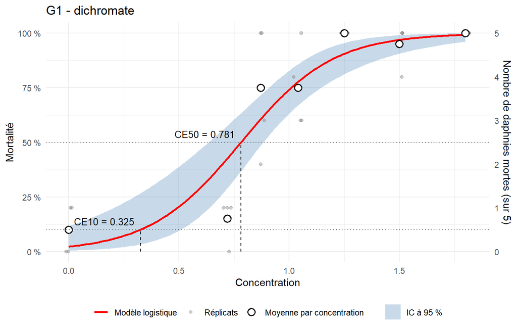

```r
graphique_modele(fit, dat, "G1 - dichromate")
```

## Tests des hypothèses

```r
# 1. Effet de la concentration
anova(fit, test = "Chisq")
```

```
## Analysis of Deviance Table
##
## Model: binomial, link: logit
##
## Response: cbind(morts, vivantes)
##
## Terms added sequentially (first to last)
##
##
##      Df Deviance Resid. Df Resid. Dev  Pr(>Chi)
## NULL                    27    115.337
## conc  1   77.923        26     37.414 < 2.2e-16 ***
## ---
## Signif. codes:  0 '***' 0.001 '**' 0.01 '*' 0.05 '.' 0.1 ' ' 1
```

```r
# 2. Loi binomiale : X²/ddl proche de 1 ? (sinon surdispersion)
X2 <- sum(residuals(fit, type = "pearson")^2)
X2 / fit$df.residual
```

```
## [1] 1.521836
```

```r
pchisq(X2, fit$df.residual, lower.tail = FALSE)
```

```
## [1] 0.0429898
```

```r
# 3. Le logit est-il une droite ? Comparaison avec le modèle "une proportion par concentration"
fit_facteur <- glm(cbind(morts, vivantes) ~ factor(conc), family = binomial, data = dat)
anova(fit, fit_facteur, test = "Chisq")
```

```
## Analysis of Deviance Table
##
## Model 1: cbind(morts, vivantes) ~ conc
## Model 2: cbind(morts, vivantes) ~ factor(conc)
##   Resid. Df Resid. Dev Df Deviance Pr(>Chi)
## 1        26     37.414
## 2        21     20.890  5   16.524 0.005497 **
## ---
## Signif. codes:  0 '***' 0.001 '**' 0.01 '*' 0.05 '.' 0.1 ' ' 1
```

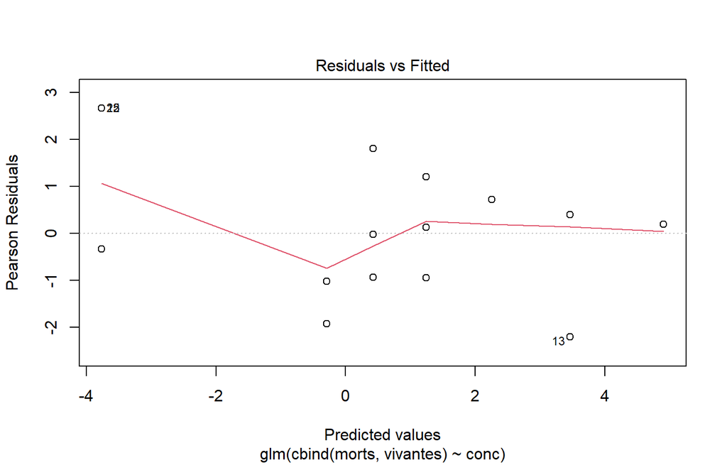

```r
# 4. Points aberrants
plot(fit, which = 1)
```

# Jeu G4 : diclofénac

```r
d <- read.table("tableau_taux_survie_diclo_G4.csv", sep = ";", header = TRUE,
                fileEncoding = "UTF-8-BOM")
morts <- round(n * (1 - d[, 3:ncol(d)] / 100))
dat <- data.frame(conc  = rep(d$concentration, ncol(morts)),
                  morts = as.vector(as.matrix(morts)))
dat$vivantes <- n - dat$morts

fit <- glm(cbind(morts, vivantes) ~ conc, family = binomial, data = dat)
summary(fit)
```

```
##
## Call:
## glm(formula = cbind(morts, vivantes) ~ conc, family = binomial,
##     data = dat)
##
## Coefficients:
##              Estimate Std. Error z value Pr(>|z|)
## (Intercept) -3.753538   0.573106  -6.549 5.77e-11 ***
## conc         0.056143   0.009404   5.970 2.37e-09 ***
## ---
## Signif. codes:  0 '***' 0.001 '**' 0.01 '*' 0.05 '.' 0.1 ' ' 1
##
## (Dispersion parameter for binomial family taken to be 1)
##
##     Null deviance: 85.622  on 27  degrees of freedom
## Residual deviance: 26.726  on 26  degrees of freedom
## AIC: 59.203
##
## Number of Fisher Scoring iterations: 5
```

```r
dose.p(fit, p = c(0.5, 0.1))
```

```
##              Dose       SE
## p = 0.5: 66.85685 4.704459
## p = 0.1: 27.72057 6.303687
```

## Graphique

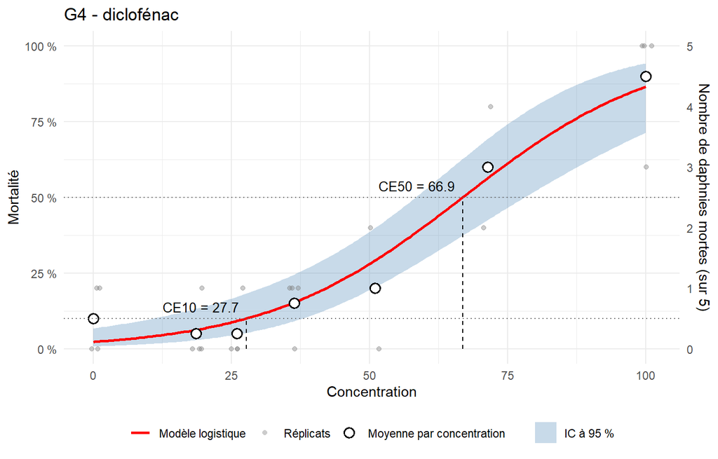

```r
graphique_modele(fit, dat, "G4 - diclofénac")
```

## Tests des hypothèses

```r
anova(fit, test = "Chisq")
```

```
## Analysis of Deviance Table
##
## Model: binomial, link: logit
##
## Response: cbind(morts, vivantes)
##
## Terms added sequentially (first to last)
##
##
##      Df Deviance Resid. Df Resid. Dev  Pr(>Chi)
## NULL                    27     85.622
## conc  1   58.896        26     26.726 1.662e-14 ***
## ---
## Signif. codes:  0 '***' 0.001 '**' 0.01 '*' 0.05 '.' 0.1 ' ' 1
```

```r
X2 <- sum(residuals(fit, type = "pearson")^2)
X2 / fit$df.residual
```

```
## [1] 1.156863
```

```r
pchisq(X2, fit$df.residual, lower.tail = FALSE)
```

```
## [1] 0.2643739
```

```r
fit_facteur <- glm(cbind(morts, vivantes) ~ factor(conc), family = binomial, data = dat)
anova(fit, fit_facteur, test = "Chisq")
```

```
## Analysis of Deviance Table
##
## Model 1: cbind(morts, vivantes) ~ conc
## Model 2: cbind(morts, vivantes) ~ factor(conc)
##   Resid. Df Resid. Dev Df Deviance Pr(>Chi)
## 1        26     26.727
## 2        21     22.042  5   4.6845   0.4556
```

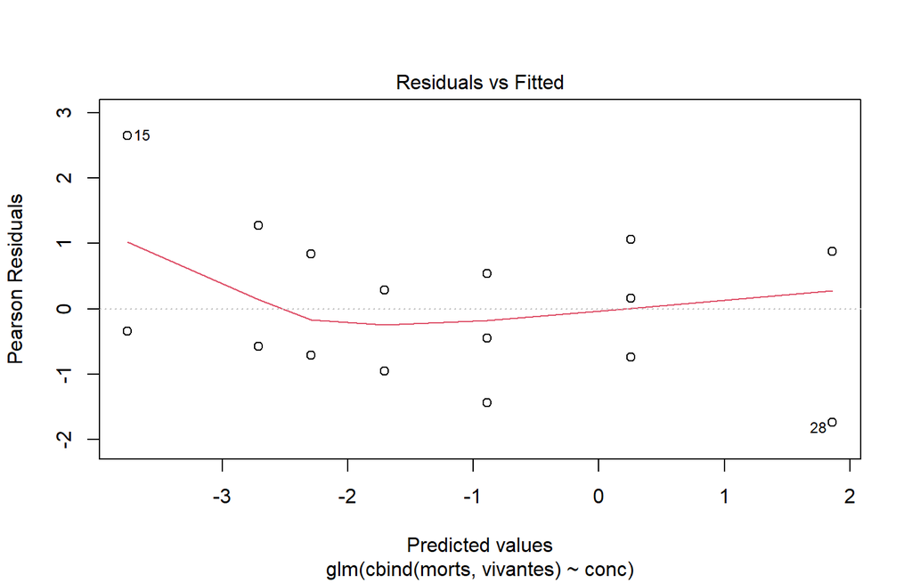

```r
plot(fit, which = 1)
```

# Jeu G6 : diclofénac

```r
d <- read.table("tableau_taux_survie_diclo_G6.csv", sep = ";", header = TRUE,
                fileEncoding = "UTF-8-BOM")
morts <- round(n * (1 - d[, 3:ncol(d)] / 100))
dat <- data.frame(conc  = rep(d$concentration, ncol(morts)),
                  morts = as.vector(as.matrix(morts)))
dat$vivantes <- n - dat$morts

fit <- glm(cbind(morts, vivantes) ~ conc, family = binomial, data = dat)
summary(fit)
```

```
##
## Call:
## glm(formula = cbind(morts, vivantes) ~ conc, family = binomial,
##     data = dat)
##
## Coefficients:
##              Estimate Std. Error z value Pr(>|z|)
## (Intercept) -3.488568   0.448214  -7.783 7.07e-15 ***
## conc         0.046427   0.006954   6.677 2.45e-11 ***
## ---
## Signif. codes:  0 '***' 0.001 '**' 0.01 '*' 0.05 '.' 0.1 ' ' 1
##
## (Dispersion parameter for binomial family taken to be 1)
##
##     Null deviance: 109.295  on 35  degrees of freedom
## Residual deviance:  44.708  on 34  degrees of freedom
## AIC: 74.633
##
## Number of Fisher Scoring iterations: 4
```

```r
dose.p(fit, p = c(0.5, 0.1))
```

```
##              Dose       SE
## p = 0.5: 75.14154 5.824621
## p = 0.1: 27.81471 6.459978
```

## Graphique

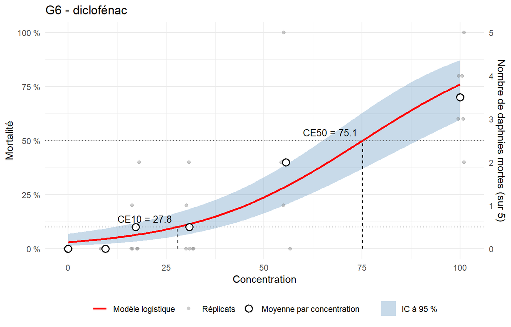

```r
graphique_modele(fit, dat, "G6 - diclofénac")
```

## Tests des hypothèses

```r
anova(fit, test = "Chisq")
```

```
## Analysis of Deviance Table
##
## Model: binomial, link: logit
##
## Response: cbind(morts, vivantes)
##
## Terms added sequentially (first to last)
##
##
##      Df Deviance Resid. Df Resid. Dev  Pr(>Chi)
## NULL                    35    109.295
## conc  1   64.588        34     44.708 9.234e-16 ***
## ---
## Signif. codes:  0 '***' 0.001 '**' 0.01 '*' 0.05 '.' 0.1 ' ' 1
```

```r
X2 <- sum(residuals(fit, type = "pearson")^2)
X2 / fit$df.residual
```

```
## [1] 1.291923
```

```r
pchisq(X2, fit$df.residual, lower.tail = FALSE)
```

```
## [1] 0.1185452
```

```r
fit_facteur <- glm(cbind(morts, vivantes) ~ factor(conc), family = binomial, data = dat)
anova(fit, fit_facteur, test = "Chisq")
```

```
## Analysis of Deviance Table
##
## Model 1: cbind(morts, vivantes) ~ conc
## Model 2: cbind(morts, vivantes) ~ factor(conc)
##   Resid. Df Resid. Dev Df Deviance Pr(>Chi)
## 1        34     44.708
## 2        30     37.181  4   7.5263   0.1106
```

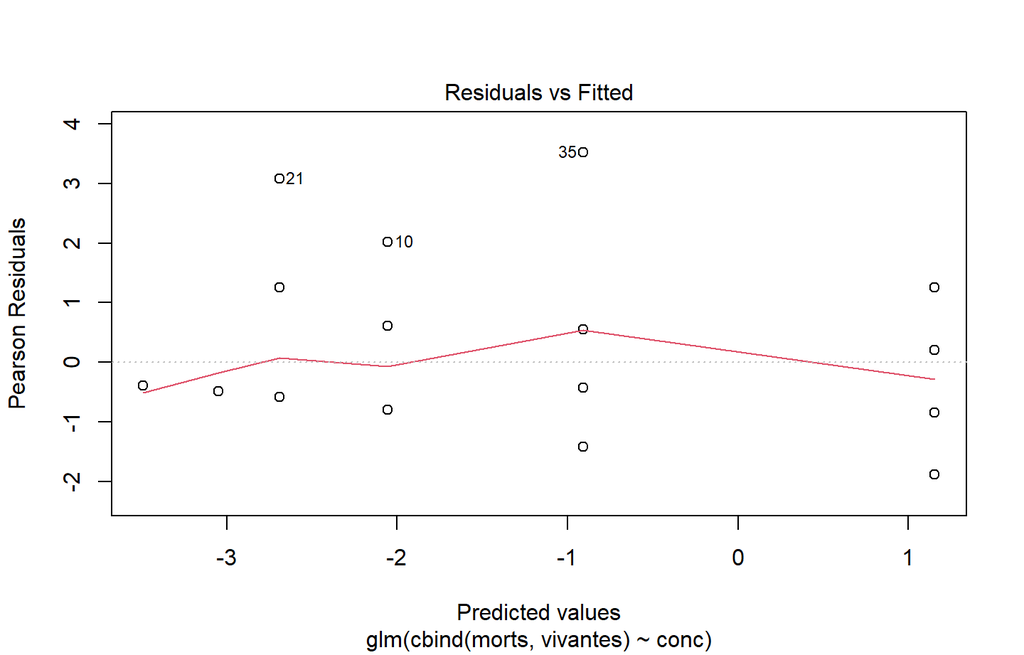

```r
plot(fit, which = 1)
```

# Résultats et interprétation

Valeurs indicatives, à comparer avec votre sortie R (unité = celle de la colonne `concentration`) :

| Jeu | CE50 | CE10 | Effet de la conc. | X²/ddl (p) | Test de la droite (p) |
| --- | --- | --- | --- | --- | --- |
| G1 dichromate | ≈ 0,78 | ≈ 0,33 | très significatif | 1,5 (0,04) | 0,005 |
| G4 diclofénac | ≈ 67 | ≈ 28 | très significatif | 1,16 (0,26) | 0,46 |
| G6 diclofénac | ≈ 75 | ≈ 28 | très significatif | 1,29 (0,12) | 0,11 |

- **G4 et G6** : le modèle convient. Les p-values des tests 2 et 3 sont supérieures à 0,05, donc on ne rejette ni la loi binomiale ni la forme en droite du logit. G6 a une légère surdispersion, due à un réplicat à 55,6 où les 5 daphnies sont mortes (visible sur le graphique des résidus). Les CE de G4 et G6 sont cohérentes entre elles (CE50 autour de 70).
- **G1** : la concentration a un effet net, mais le modèle s’ajuste moins bien : le test de la droite est rejeté (p ≈ 0,005) et il y a un peu de surdispersion. La courbe réelle est plus raide que la courbe logistique. La CE50 reste utilisable, la CE10 est à prendre avec prudence.
- **CE10 en général** : elle est moins précise que la CE50 (écart-type plus grand), car elle se situe dans la queue de la courbe. De plus, les témoins de G1 et G4 ont 10 % de mortalité : la CE10 est donc proche de la mortalité naturelle.